# DSC478 Project - Modeling (Mourad)

## Credit Card Customers Churn

After cleaning and anlyzing the data, the cleaned dataset is split into **training and testing datasets**. The training dataset is used for tuning and validation, while the testing dataset is heldout for final evaluations.

The process used for modeling is performed by setting up a pipeline that executes two steps. The first step is preprocessing (scaling and encoding), then the second step is applying the estimator (classifier). The pipeline is passed into a grid search for tuning the hyperparameters of the classifier. The models are also tuned using the class_weight parameter to counter the imbalance of the target variable. Different class weight multipliers are evaluated to achieve the best outcomes. This process is repeated for each estimator, and the results are collected, compared, and presented for analysis.

Based on external readings, the ROC AUC score is not the best-scoring method when the data is imbalanced, so the F1/recall/precision scores will be used for best model selection.

The grid search is executed using the training dataset and applies 5-folds cross-validations to find the best hyperparameter combination to achieve the best bias/variance trade-off point. The classification scores [f1, recall, precision, balanced_accuracy, accuracy, roc auc] are collected for each classifier with its best hyperparameters, but the f1 score is the main balanced score influences the decision making and the best model selection.

During the hyperparameters tuning, the tuning begins by using a wide range for each parameter, and then after each run, the range is reduced and converged toward the best scale. This process is repeated until a constant parameter is decided or a reasonable range is identified to help present the hyper parameters' effect on the bias/variance trade-off points.

After each grid search, the results are presented for the best estimator hyperparameter configuration with the cross-validation training and validation scores. A plot presents the bias/variance at each hyperparameter combination tested, and the best configuration is highlighted at the index matching the best configuration. Each configuration's details are then presented in a tabular format indexed to match the plot x-axis numbers, including all the details of the parameters and the scores achieved with this configuration.

For each tuned estimator, the best model is tested against the testing dataset to get the final scores that will be compared for the final models' evaluation.

Finally, the best configuration and scores are presented in a tabular format to compare the estimators.

```python
import pandas as pd
import numpy as np
import klib
import pandas_profiling as pp
import sweetviz
import sklearn

import matplotlib.pyplot as plt
import seaborn as sns
import graphviz

from sklearn.model_selection import train_test_split
from sklearn.preprocessing import StandardScaler
from sklearn.preprocessing import MinMaxScaler
from sklearn.preprocessing import OneHotEncoder
from sklearn.preprocessing import OrdinalEncoder
from sklearn.preprocessing import LabelEncoder
from sklearn.compose import ColumnTransformer
from sklearn.compose import make_column_transformer
from sklearn.pipeline import Pipeline
from sklearn.feature_selection import *
from sklearn.metrics import *

from sklearn import set_config
from sklearn.utils import estimator_html_repr
from IPython.core.display import display, HTML

set_config(display='diagram')
from platform import python_version

%precision 2

pd.options.display.max_rows = 100
pd.options.display.max_columns = 100
pd.options.display.width = 120
pd.options.display.float_format='{:,.2f}'.format
pd.options.display.precision = 2

np.set_printoptions(precision=2, linewidth=120, suppress=True, edgeitems=5)

sns.set_style("white")

StartBold = "\033[1m"
EndBold = "\033[0m"

print('python',python_version())
print(np.__name__, np.__version__)
print(pd.__name__, pd.__version__)
print(klib.__name__, klib.__version__)
#print(pp.__name__, pp.__version__)
print(sklearn.__name__, sklearn.__version__)
print(sweetviz.__name__, sweetviz.__version__)
```

```
python 3.9.2
numpy 1.20.1
pandas 1.1.4
klib 0.1.5
sklearn 0.24.1
sweetviz 2.0.9
```

```python
from sklearn.model_selection import GridSearchCV
from sklearn.model_selection import cross_validate

from sklearn import metrics
```

```python
%%html
<style>
.jp-RenderedMarkdown {
    font-size:130%;
}
.CodeMirror, .CodeMirror pre, .CodeMirror-dialog, .CodeMirror-dialog .CodeMirror-search-field, .terminal-app .terminal {
    font-size: 80%;
}
</style>
```

```python
%matplotlib inline
%config InlineBackend.figure_formats = ['retina']
#%config InlineBackend.figure_formats = ['png', 'retina', 'jpeg', 'svg', 'pdf']
```

```python
from sklearn import set_config
set_config(display='diagram')
```

```python
# Global Parameters

random_state = 2021
n_jobs = 4
```

| Variable | Type | Description |
| --- | --- | --- |
| Clientnum | Num | Client number. Unique identifier for the customer holding the account |
| Attrition_Flag | Char | Internal event (customer activity) variable - if the account is closed then 1 else 0 |
| Customer_Age | Num | Demographic variable - Customer's Age in Years |
| Gender | Char | Demographic variable - M=Male, F=Female |
| Dependent_count | Num | Demographic variable - Number of dependents |
| Education_Level | Char | Demographic variable - Educational Qualification of the account holder (example: high school, college graduate, etc.) |
| Marital_Status | Char | Demographic variable - Married, Single, Unknown |
| Income_Category | Char | Demographic variable - Annual Income Category of the account holder (< $40K, $40K - 60K, $60K - $80K, $80K-$120K, > $120K, Unknown) |
| Card_Category | Char | Product Variable - Type of Card (Blue, Silver, Gold, Platinum) |
| Months_on_book | Num | Months on book (Time of Relationship) |
| Total_Relationship_Count | Num | Total no. of products held by the customer |
| Months_Inactive_12_mon | Num | No. of months inactive in the last 12 months |
| Contacts_Count_12_mon | Num | No. of Contacts in the last 12 months |
| Credit_Limit | Num | Credit Limit on the Credit Card |
| Total_Revolving_Bal | Num | Total Revolving Balance on the Credit Card |
| Avg_Open_To_Buy | Num | Open to Buy Credit Line (Average of last 12 months) |
| Total_Amt_Chng_Q4_Q1 | Num | Change in Transaction Amount (Q4 over Q1) |
| Total_Trans_Amt | Num | Total Transaction Amount (Last 12 months) |
| Total_Trans_Ct | Num | Total Transaction Count (Last 12 months) |
| Total_Ct_Chng_Q4_Q1 | Num | Change in Transaction Count (Q4 over Q1) |
| Avg_Utilization_Ratio | Num | Average Card Utilization Ratio |

## Read **Train dataset** for Training and Validation

```python
# Read [Train] data from CSV
df_train = pd.read_csv('./data/bank_churners_train.csv', index_col=0)
X = df_train.iloc[:,:-1]
y = df_train.attrited_customer
print('X and y shapes:')
print(X.shape,y.shape,'\n')
print('Target Ratio:')
print(y.value_counts(normalize=True, dropna=False),'\n')
df_train.info()
```

```
X and y shapes:
(8101, 19) (8101,)

Target Ratio:
False   0.84
True    0.16
Name: attrited_customer, dtype: float64

<class 'pandas.core.frame.DataFrame'>
Int64Index: 8101 entries, 3066 to 1919
Data columns (total 20 columns):
 #   Column                    Non-Null Count  Dtype
---  ------                    --------------  -----
 0   customer_age              8101 non-null   int64
 1   dependent_count           8101 non-null   int64
 2   months_on_book            8101 non-null   int64
 3   total_relationship_count  8101 non-null   int64
 4   months_inactive_12_mon    8101 non-null   int64
 5   contacts_count_12_mon     8101 non-null   int64
 6   credit_limit              8101 non-null   float64
 7   total_revolving_bal       8101 non-null   int64
 8   avg_open_to_buy           8101 non-null   float64
 9   total_amt_chng_q4_q1      8101 non-null   float64
 10  total_trans_amt           8101 non-null   int64
 11  total_trans_ct            8101 non-null   int64
 12  total_ct_chng_q4_q1       8101 non-null   float64
 13  avg_utilization_ratio     8101 non-null   float64
 14  gender                    8101 non-null   object
 15  education_level           8101 non-null   object
 16  marital_status            8101 non-null   object
 17  income_category           8101 non-null   object
 18  card_category             8101 non-null   object
 19  attrited_customer         8101 non-null   bool
dtypes: bool(1), float64(5), int64(9), object(5)
memory usage: 1.2+ MB
```

## Read **Test dataset** for Final Model evaluation

```python
# Read [Test] data from CSV
df_test = pd.read_csv('./data/bank_churners_test.csv', index_col=0)
X_test = df_test.iloc[:,:-1]
y_test = df_test.attrited_customer
print('X and y shapes:')
print(X_test.shape,y_test.shape,'\n')
print('Target Ratio:')
print(y_test.value_counts(normalize=True, dropna=False),'\n')
```

```
X and y shapes:
(2026, 19) (2026,)

Target Ratio:
False   0.84
True    0.16
Name: attrited_customer, dtype: float64
```

# Extract Features Names

```python
features_numeric     = list(df_train.columns[:14])
features_nominal     = ['gender','marital_status']
features_nominal_ohe = ['is_Female', 'is_Male', 'is_Divorced', 'is_Married', 'is_Single','is_Unknown_Marital'] # OneHotEncoded
features_ordinal     = ['education_level','income_category','card_category']
features_names       = df_train.columns[:19].values
features_names_enc   =  features_numeric + features_ordinal + features_nominal_ohe
```

# Helper Functions

These functions are to help me do repetitive tasks and better present my results

```python
def get_GS_cv_results(gs):
    '''
        Extract Grid Seach Results
        Author: Mourad Askar
    '''
    _cv_results_ = gs.cv_results_
    _scorer_keys = gs.scorer_.keys()

    df_gs_scores = pd.DataFrame()

    for k in _cv_results_.keys():
        if k.startswith('param_'):
            param_key = ('param',k.split('_',1)[1])
            param_values = _cv_results_[k]
            df_gs_scores = pd.concat([df_gs_scores,pd.DataFrame({param_key:param_values})], axis=1)

        elif k.startswith('mean_train') or k.startswith('mean_test'):
            score_key = (k.split('_',2)[2],k.split('_',2)[1])
            score_results = _cv_results_[k]
            df_gs_scores = pd.concat([df_gs_scores,pd.DataFrame({score_key:score_results})], axis=1)

    return df_gs_scores

def display_grid_search_scores_grid(gs):
    '''
        Display Grid Search Scores Table
        Author: Mourad Askar
    '''
    _cv_results_ = gs.cv_results_
    _scorer_keys = gs.scorer_.keys()
    _param_keys = list(_cv_results_['params'][0].keys())
    df_gs_scores = get_GS_cv_results(gs)

    display(df_gs_scores)


def plot_grid_search_results(gs, plot_scoring='f1'):
    '''
        Plot Grid Search Train/Val Scores
        Author: Mourad Askar
    '''
    _cv_results_ = gs.cv_results_
    _scorer_keys = gs.scorer_.keys()

    if(type(gs) == GridSearchCV):
        model = gs.best_estimator_
        if(type(model) == Pipeline):
            model = gs.best_estimator_.named_steps.classifier
    else:
        model = gs

    print(f'{StartBold}Estimator:{EndBold}')
    display(model)
    print()
    print(f'{StartBold}Best Result (Suggested):{EndBold}')
    print(f'{StartBold}\t{"":20} {"train":>6} {"valdn":>6}{EndBold}')
    for _score in _scorer_keys:
        print('\t{2:>20} {0:>6.2f} {1:>6.2f}'.format(_cv_results_['mean_train_' + _score][gs.best_index_],
                                             _cv_results_['mean_test_' + _score][gs.best_index_],
                                             _score))
    print()
    print(f'{StartBold}Params:{EndBold}')
    print('\t{}'.format(gs.best_params_))
    print()


    scoring_label = plot_scoring
    not_negative = 1
    if plot_scoring.startswith('neg_'):
        scoring_label = plot_scoring[4:]
        not_negative = -1
    df = pd.DataFrame({
        'params': _cv_results_['params'],
        'mean_train_' + plot_scoring: _cv_results_['mean_train_' + plot_scoring] * not_negative,
        'mean_test_' + plot_scoring: _cv_results_['mean_test_' + plot_scoring] * not_negative
    })
    fig, ax = plt.subplots()
    df.plot('params',['mean_train_' + plot_scoring,'mean_test_' + plot_scoring], 'line', ax=ax)
    ax.axvline(gs.best_index_,0,1, color='r', linestyle='--')
    plt.grid(axis='both',c='lightgrey',ls=':')
    plt.xticks(ticks=range(df.params.count()), labels=df.index)
    plt.tick_params(axis='x', rotation=0)
    plt.xlabel('params index')
    plt.ylabel(scoring_label)
    plt.legend(['train','valdn'])
    plt.show()

    #_ = gs
    #df_ = pd.DataFrame(_.cv_results_).filter(regex='(?:mean_test)|(?:params)')
    #df_.insert(0,'classifier',_.best_estimator_.named_steps.classifier.__class__.__name__)
    #d_result = {_.best_estimator_.named_steps.classifier:dict(df_.iloc[_.best_index_])}
    #d_result
    display_grid_search_scores_grid(gs)

    if("beep" in globals()): beep(True)

def score_classification_model(fitted_model, X, y_true, return_score=False):
    '''
        Print Classification Metrics
        Author: Mourad Askar
    '''
    p = fitted_model.predict(X)

    accuracy = metrics.accuracy_score(y_true, p)
    f1 = metrics.f1_score(y_true, p)
    recall = metrics.recall_score(y_true, p)
    precision = metrics.precision_score(y_true, p)
    balanced_accuracy = metrics.balanced_accuracy_score(y_true, p)
    roc = metrics.roc_auc_score(y_true, p)

    print('\taccuracy score:          {:>5.2f}'.format(accuracy))
    print('\tf1 score:                {:>5.2f}'.format(f1))
    print('\trecall score:            {:>5.2f}'.format(recall))
    print('\tprecision score:         {:>5.2f}'.format(precision))
    print('\tbalanced_accuracy score: {:>5.2f}'.format(balanced_accuracy))
    print('\troc_auc score:           {:>5.2f}'.format(roc))

    #print(metrics.classification_report(y_true,p))
    metrics.plot_confusion_matrix(fitted_model,X, y_true)
    plt.show()

    #print(metrics.classification_report(y_true,p, sample_weight=compute_sample_weight('balanced',y_true)))
    #metrics.plot_confusion_matrix(fitted_model,X, y_true, sample_weight=compute_sample_weight('balanced',y_true))

    if((type(return_score) is str) or return_score):
        if(type(fitted_model) == GridSearchCV):
            model = fitted_model.best_estimator_
            if(type(model) == Pipeline):
                model = fitted_model.best_estimator_.named_steps.classifier
        else:
            model = fitted_model
        key = str(model).replace('\n','') + ( (' - ' + return_score) if type(return_score) == str else '')
        results_dict = {key : {}}
        results_dict[key]['Estimator'] = model.__class__.__name__
        results_dict[key]['TAG'] = return_score if type(return_score) == str else '-'
        results_dict[key]['Accuracy'] = accuracy
        results_dict[key]['F1'] = f1
        results_dict[key]['Recall'] = recall
        results_dict[key]['Precision'] = precision
        results_dict[key]['Balanced_Accuracy'] = balanced_accuracy
        results_dict[key]['ROC_AUC'] = roc
        return(results_dict)

def plot_coefficients(coef, feature_names, top_n=0):
    '''
        Plot Coefficents Magnitude
        Author: Mourad Askar
    '''
    _ = pd.DataFrame({'features':feature_names,'coef':coef}).sort_values('coef',key=lambda x: abs(x),ascending=False)
    if top_n > 0:
        _ = _.iloc[:top_n,:]
    n_features = _.shape[0]
    #plt.subplots(figsize=(10,20))
    plt.barh(range(n_features), _['coef'], align='center')
    plt.yticks(np.arange(n_features), _['features'])
    plt.xlabel('Value')
    plt.ylabel('Feature')
    plt.ylim(n_features,-1)
    plt.show()
```

# Pipeline and Grid Search Setup

I ignord the dummy features created in the first notebook, and decided to make it part of the pipeline to have more control over the ordinal vs nominal features.

I encoded the nominal features using OneHotencoder, and encoded the ordinals features using the Ordinal Encoder.

```python
from sklearn.tree import DecisionTreeClassifier
from sklearn.ensemble import RandomForestClassifier
from sklearn.linear_model import LogisticRegression, SGDClassifier
from sklearn.svm import SVC
```

```python
numeric_transformer = StandardScaler()
nominal_transformer = OneHotEncoder()
ordinal_transformer = OrdinalEncoder()

preprocessor = ColumnTransformer(
    transformers=[
        ('numeric', numeric_transformer, features_numeric),
        ('nominal', nominal_transformer, features_nominal),
        ('ordinal', ordinal_transformer, features_ordinal),
    ])

clf = Pipeline(
    steps=[
        ('preprocessor', preprocessor),
        ('classifier', SGDClassifier())
    ])

display(clf)
```

## Common GridSearch Params

```python
# Common Grid Search Parameters that will be use across all models

grid_search_defaults = {
    'cv': 5,
    'scoring': ['f1', 'recall', 'precision', 'balanced_accuracy', 'accuracy', 'roc_auc'],
    'refit': 'f1',
    'return_train_score': True,
    'error_score': 0,
    'verbose': 3,
    'n_jobs': n_jobs,
}
```

# Modeling

## Initialize Scores Dictionary

```python
# Dictionary to collect the scores from different models
scores_TestSet = {}
```

## SGDClassifier

```
Fitting 5 folds for each of 25 candidates, totalling 125 fits


Train_Set Tuning Results:
Estimator:
```

```
Best Result (Suggested):
	                      train  valdn
	                  f1   0.69   0.69
	              recall   0.71   0.70
	           precision   0.68   0.68
	   balanced_accuracy   0.82   0.82
	            accuracy   0.90   0.90
	             roc_auc   0.93   0.92

Params:
	{'classifier__alpha': 0.00316, 'classifier__l1_ratio': 0}
```

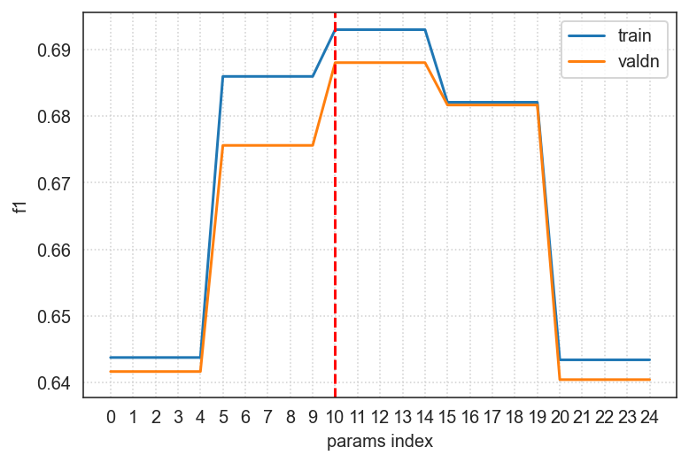

|  | param classifier__alpha | param classifier__l1_ratio | f1 test | f1 train | recall test | recall train | precision test | precision train | balanced_accuracy test | balanced_accuracy train | accuracy test | accuracy train | roc_auc test | roc_auc train |
| --- | --- | --- | --- | --- | --- | --- | --- | --- | --- | --- | --- | --- | --- | --- |
| 0 | 0.00 | 0 | 0.64 | 0.64 | 0.75 | 0.76 | 0.57 | 0.57 | 0.82 | 0.82 | 0.86 | 0.86 | 0.91 | 0.91 |
| 1 | 0.00 | 0.25 | 0.64 | 0.64 | 0.75 | 0.76 | 0.57 | 0.57 | 0.82 | 0.82 | 0.86 | 0.86 | 0.91 | 0.91 |
| 2 | 0.00 | 0.50 | 0.64 | 0.64 | 0.75 | 0.76 | 0.57 | 0.57 | 0.82 | 0.82 | 0.86 | 0.86 | 0.91 | 0.91 |
| 3 | 0.00 | 0.75 | 0.64 | 0.64 | 0.75 | 0.76 | 0.57 | 0.57 | 0.82 | 0.82 | 0.86 | 0.86 | 0.91 | 0.91 |
| 4 | 0.00 | 1 | 0.64 | 0.64 | 0.75 | 0.76 | 0.57 | 0.57 | 0.82 | 0.82 | 0.86 | 0.86 | 0.91 | 0.91 |
| 5 | 0.00 | 0 | 0.68 | 0.69 | 0.73 | 0.74 | 0.63 | 0.64 | 0.82 | 0.83 | 0.89 | 0.89 | 0.92 | 0.92 |
| 6 | 0.00 | 0.25 | 0.68 | 0.69 | 0.73 | 0.74 | 0.63 | 0.64 | 0.82 | 0.83 | 0.89 | 0.89 | 0.92 | 0.92 |
| 7 | 0.00 | 0.50 | 0.68 | 0.69 | 0.73 | 0.74 | 0.63 | 0.64 | 0.82 | 0.83 | 0.89 | 0.89 | 0.92 | 0.92 |
| 8 | 0.00 | 0.75 | 0.68 | 0.69 | 0.73 | 0.74 | 0.63 | 0.64 | 0.82 | 0.83 | 0.89 | 0.89 | 0.92 | 0.92 |
| 9 | 0.00 | 1 | 0.68 | 0.69 | 0.73 | 0.74 | 0.63 | 0.64 | 0.82 | 0.83 | 0.89 | 0.89 | 0.92 | 0.92 |
| 10 | 0.00 | 0 | 0.69 | 0.69 | 0.70 | 0.71 | 0.68 | 0.68 | 0.82 | 0.82 | 0.90 | 0.90 | 0.92 | 0.93 |
| 11 | 0.00 | 0.25 | 0.69 | 0.69 | 0.70 | 0.71 | 0.68 | 0.68 | 0.82 | 0.82 | 0.90 | 0.90 | 0.92 | 0.93 |
| 12 | 0.00 | 0.50 | 0.69 | 0.69 | 0.70 | 0.71 | 0.68 | 0.68 | 0.82 | 0.82 | 0.90 | 0.90 | 0.92 | 0.93 |
| 13 | 0.00 | 0.75 | 0.69 | 0.69 | 0.70 | 0.71 | 0.68 | 0.68 | 0.82 | 0.82 | 0.90 | 0.90 | 0.92 | 0.93 |
| 14 | 0.00 | 1 | 0.69 | 0.69 | 0.70 | 0.71 | 0.68 | 0.68 | 0.82 | 0.82 | 0.90 | 0.90 | 0.92 | 0.93 |
| 15 | 0.02 | 0 | 0.68 | 0.68 | 0.67 | 0.67 | 0.70 | 0.70 | 0.81 | 0.81 | 0.90 | 0.90 | 0.92 | 0.92 |
| 16 | 0.02 | 0.25 | 0.68 | 0.68 | 0.67 | 0.67 | 0.70 | 0.70 | 0.81 | 0.81 | 0.90 | 0.90 | 0.92 | 0.92 |
| 17 | 0.02 | 0.50 | 0.68 | 0.68 | 0.67 | 0.67 | 0.70 | 0.70 | 0.81 | 0.81 | 0.90 | 0.90 | 0.92 | 0.92 |
| 18 | 0.02 | 0.75 | 0.68 | 0.68 | 0.67 | 0.67 | 0.70 | 0.70 | 0.81 | 0.81 | 0.90 | 0.90 | 0.92 | 0.92 |
| 19 | 0.02 | 1 | 0.68 | 0.68 | 0.67 | 0.67 | 0.70 | 0.70 | 0.81 | 0.81 | 0.90 | 0.90 | 0.92 | 0.92 |
| 20 | 0.10 | 0 | 0.64 | 0.64 | 0.56 | 0.57 | 0.74 | 0.74 | 0.76 | 0.76 | 0.90 | 0.90 | 0.90 | 0.90 |
| 21 | 0.10 | 0.25 | 0.64 | 0.64 | 0.56 | 0.57 | 0.74 | 0.74 | 0.76 | 0.76 | 0.90 | 0.90 | 0.90 | 0.90 |
| 22 | 0.10 | 0.50 | 0.64 | 0.64 | 0.56 | 0.57 | 0.74 | 0.74 | 0.76 | 0.76 | 0.90 | 0.90 | 0.90 | 0.90 |
| 23 | 0.10 | 0.75 | 0.64 | 0.64 | 0.56 | 0.57 | 0.74 | 0.74 | 0.76 | 0.76 | 0.90 | 0.90 | 0.90 | 0.90 |
| 24 | 0.10 | 1 | 0.64 | 0.64 | 0.56 | 0.57 | 0.74 | 0.74 | 0.76 | 0.76 | 0.90 | 0.90 | 0.90 | 0.90 |

```
Test_Set Results:
	accuracy score:           0.89
	f1 score:                 0.68
	recall score:             0.70
	precision score:          0.66
	balanced_accuracy score:  0.82
	roc_auc score:            0.82
```

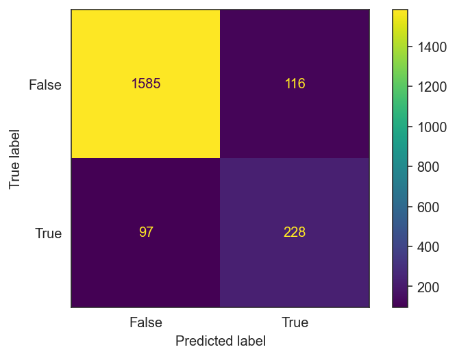

```python
cl_pl = Pipeline(
    steps=[
        ('preprocessor', preprocessor),
        ('classifier', SGDClassifier(loss='log',n_jobs=n_jobs,class_weight={1:2},random_state=random_state))
    ]
)

params = {
#    'classifier__class_weight': ['balanced',{1:2},{1:3},{1:4}],
    'classifier__l1_ratio': [0,.25,.5,.75,1],
    'classifier__alpha': np.logspace(-4,-1,5).round(5),
#    'classifier__alpha': [.0006,.0007,.0008],
}
gs = GridSearchCV(
    cl_pl,
    params, **grid_search_defaults
)
gs.fit(
    X,
    y
)

print(f'\n\n{StartBold}Train_Set Tuning Results:{EndBold}')
plot_grid_search_results(gs, grid_search_defaults['refit'])
print(f'\n\n{StartBold}Test_Set Results:{EndBold}')
results = score_classification_model(gs, X_test, y_test, True)
scores_TestSet.update(results)
```

## Decision Tree Classification

```
Fitting 5 folds for each of 12 candidates, totalling 60 fits


Train_Set Tuning Results:
Estimator:
```

```
Best Result (Suggested):
	                      train  valdn
	                  f1   0.85   0.80
	              recall   0.88   0.83
	           precision   0.82   0.77
	   balanced_accuracy   0.92   0.89
	            accuracy   0.95   0.93
	             roc_auc   0.98   0.95

Params:
	{'classifier__max_depth': 8, 'classifier__min_samples_split': 0.01}
```

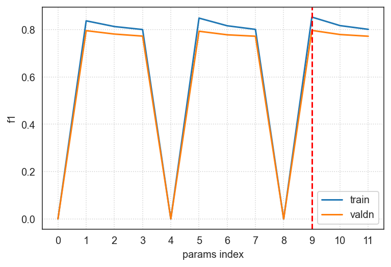

|  | param classifier__max_depth | param classifier__min_samples_split | f1 test | f1 train | recall test | recall train | precision test | precision train | balanced_accuracy test | balanced_accuracy train | accuracy test | accuracy train | roc_auc test | roc_auc train |
| --- | --- | --- | --- | --- | --- | --- | --- | --- | --- | --- | --- | --- | --- | --- |
| 0 | 6 | 0 | 0.00 | 0.00 | 0.00 | 0.00 | 0.00 | 0.00 | 0.00 | 0.00 | 0.00 | 0.00 | 0.00 | 0.00 |
| 1 | 6 | 0.01 | 0.80 | 0.84 | 0.82 | 0.86 | 0.77 | 0.81 | 0.89 | 0.91 | 0.93 | 0.95 | 0.95 | 0.97 |
| 2 | 6 | 0.02 | 0.78 | 0.81 | 0.83 | 0.86 | 0.74 | 0.77 | 0.89 | 0.91 | 0.93 | 0.94 | 0.95 | 0.97 |
| 3 | 6 | 0.03 | 0.77 | 0.80 | 0.82 | 0.85 | 0.73 | 0.75 | 0.88 | 0.90 | 0.92 | 0.93 | 0.95 | 0.97 |
| 4 | 7 | 0 | 0.00 | 0.00 | 0.00 | 0.00 | 0.00 | 0.00 | 0.00 | 0.00 | 0.00 | 0.00 | 0.00 | 0.00 |
| 5 | 7 | 0.01 | 0.79 | 0.85 | 0.83 | 0.88 | 0.76 | 0.82 | 0.89 | 0.92 | 0.93 | 0.95 | 0.96 | 0.98 |
| 6 | 7 | 0.02 | 0.78 | 0.82 | 0.84 | 0.88 | 0.72 | 0.76 | 0.89 | 0.91 | 0.92 | 0.94 | 0.96 | 0.98 |
| 7 | 7 | 0.03 | 0.77 | 0.80 | 0.82 | 0.86 | 0.73 | 0.75 | 0.88 | 0.90 | 0.92 | 0.93 | 0.96 | 0.97 |
| 8 | 8 | 0 | 0.00 | 0.00 | 0.00 | 0.00 | 0.00 | 0.00 | 0.00 | 0.00 | 0.00 | 0.00 | 0.00 | 0.00 |
| 9 | 8 | 0.01 | 0.80 | 0.85 | 0.83 | 0.88 | 0.77 | 0.82 | 0.89 | 0.92 | 0.93 | 0.95 | 0.95 | 0.98 |
| 10 | 8 | 0.02 | 0.78 | 0.82 | 0.84 | 0.88 | 0.72 | 0.76 | 0.89 | 0.91 | 0.92 | 0.94 | 0.96 | 0.98 |
| 11 | 8 | 0.03 | 0.77 | 0.80 | 0.82 | 0.86 | 0.73 | 0.75 | 0.88 | 0.90 | 0.92 | 0.93 | 0.95 | 0.97 |

```
Test_Set Results:
	accuracy score:           0.93
	f1 score:                 0.78
	recall score:             0.82
	precision score:          0.75
	balanced_accuracy score:  0.88
	roc_auc score:            0.88
```

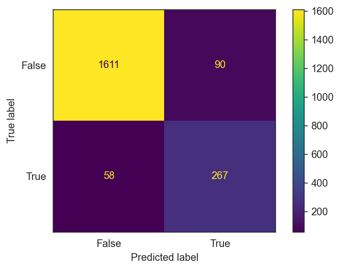

```python
cl_pl = Pipeline(
    steps=[
        ('preprocessor', preprocessor),
        ('classifier', DecisionTreeClassifier(class_weight={1:2}, random_state=random_state))
    ]
)

params = {
#    'classifier__class_weight': ['balanced',{1:2},{1:3},{1:4}],
    'classifier__max_depth': [6,7,8],
    'classifier__min_samples_split': [0,.01,.02,.03],
#    'classifier__max_features': [.1,.5,1.0],
}
gs = GridSearchCV(
    cl_pl,
    params, **grid_search_defaults
)
gs.fit(
    X,
    y
)

print(f'\n\n{StartBold}Train_Set Tuning Results:{EndBold}')
plot_grid_search_results(gs, grid_search_defaults['refit'])

print(f'\n\n{StartBold}Test_Set Results:{EndBold}')
results = score_classification_model(gs, X_test, y_test, True)
scores_TestSet.update(results)
```

## Random Forest Classification

```
Fitting 5 folds for each of 9 candidates, totalling 45 fits


Train_Set Tuning Results:
Estimator:
```

```
Best Result (Suggested):
	                      train  valdn
	                  f1   0.90   0.85
	              recall   0.92   0.87
	           precision   0.87   0.84
	   balanced_accuracy   0.95   0.92
	            accuracy   0.97   0.95
	             roc_auc   0.99   0.98

Params:
	{'classifier__max_depth': 24, 'classifier__max_features': 0.5, 'classifier__min_samples_split': 0.01}
```

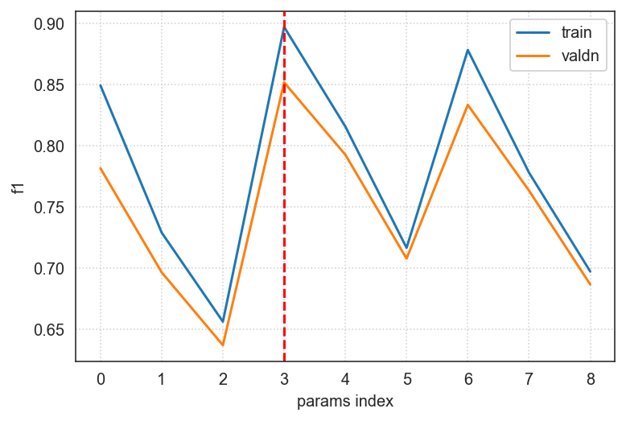

|  | param classifier__max_depth | param classifier__max_features | param classifier__min_samples_split | f1 test | f1 train | recall test | recall train | precision test | precision train | balanced_accuracy test | balanced_accuracy train | accuracy test | accuracy train | roc_auc test | roc_auc train |
| --- | --- | --- | --- | --- | --- | --- | --- | --- | --- | --- | --- | --- | --- | --- | --- |
| 0 | 24 | 0.10 | 0.01 | 0.78 | 0.85 | 0.72 | 0.81 | 0.85 | 0.89 | 0.85 | 0.90 | 0.94 | 0.95 | 0.97 | 0.99 |
| 1 | 24 | 0.10 | 0.05 | 0.70 | 0.73 | 0.60 | 0.64 | 0.84 | 0.85 | 0.79 | 0.81 | 0.92 | 0.92 | 0.95 | 0.96 |
| 2 | 24 | 0.10 | 0.10 | 0.64 | 0.66 | 0.50 | 0.52 | 0.88 | 0.89 | 0.74 | 0.75 | 0.91 | 0.91 | 0.94 | 0.95 |
| 3 | 24 | 0.50 | 0.01 | 0.85 | 0.90 | 0.87 | 0.92 | 0.84 | 0.87 | 0.92 | 0.95 | 0.95 | 0.97 | 0.98 | 0.99 |
| 4 | 24 | 0.50 | 0.05 | 0.79 | 0.82 | 0.82 | 0.86 | 0.76 | 0.78 | 0.89 | 0.91 | 0.93 | 0.94 | 0.97 | 0.97 |
| 5 | 24 | 0.50 | 0.10 | 0.71 | 0.72 | 0.68 | 0.69 | 0.73 | 0.74 | 0.82 | 0.82 | 0.91 | 0.91 | 0.94 | 0.95 |
| 6 | 24 | 1.00 | 0.01 | 0.83 | 0.88 | 0.85 | 0.90 | 0.82 | 0.86 | 0.91 | 0.94 | 0.95 | 0.96 | 0.98 | 0.99 |
| 7 | 24 | 1.00 | 0.05 | 0.76 | 0.78 | 0.84 | 0.86 | 0.70 | 0.71 | 0.89 | 0.90 | 0.92 | 0.92 | 0.96 | 0.97 |
| 8 | 24 | 1.00 | 0.10 | 0.69 | 0.70 | 0.68 | 0.70 | 0.69 | 0.70 | 0.81 | 0.82 | 0.90 | 0.90 | 0.93 | 0.94 |

```
Test_Set Results:
	accuracy score:           0.95
	f1 score:                 0.86
	recall score:             0.90
	precision score:          0.83
	balanced_accuracy score:  0.93
	roc_auc score:            0.93
```

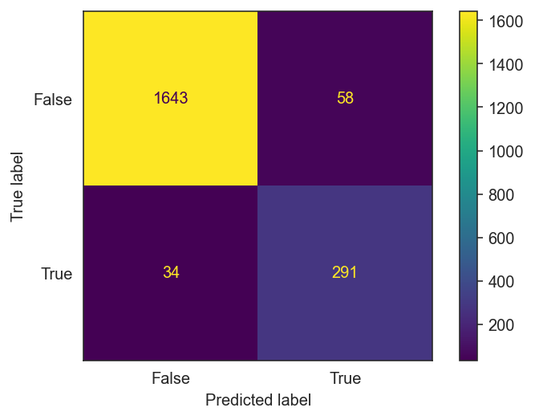

```python
cl_pl = Pipeline(
    steps=[
        ('preprocessor', preprocessor),
        ('classifier', RandomForestClassifier(class_weight={1:2},n_jobs=-1,random_state=random_state))
    ]
)

params = {
#    'classifier__class_weight': ['balanced','balanced_subsample',{1:2},{1:3},{1:4}],
#    'classifier__n_estimators': [200,300,400,500],
    'classifier__max_depth': [24], #[16,24,32],
    'classifier__min_samples_split': [.01,.05,.1],
    'classifier__max_features': [.1,.5,1.0],
}
gs = GridSearchCV(
    cl_pl,
    params, **grid_search_defaults
)
gs.fit(
    X,
    y
)

print(f'\n\n{StartBold}Train_Set Tuning Results:{EndBold}')
plot_grid_search_results(gs, grid_search_defaults['refit'])

print(f'\n\n{StartBold}Test_Set Results:{EndBold}')
results = score_classification_model(gs, X_test, y_test, True)
scores_TestSet.update(results)
```

# Test Results Table

```python
pd.DataFrame(scores_TestSet).T.drop(columns='TAG')
```

|  | Estimator | Accuracy | F1 | Recall | Precision | Balanced_Accuracy | ROC_AUC |
| --- | --- | --- | --- | --- | --- | --- | --- |
| SGDClassifier(alpha=0.00316, class_weight={1: 2}, l1_ratio=0, loss='log', n_jobs=4, random_state=2021) | SGDClassifier | 0.89 | 0.68 | 0.70 | 0.66 | 0.82 | 0.82 |
| DecisionTreeClassifier(class_weight={1: 2}, max_depth=8, min_samples_split=0.01, random_state=2021) | DecisionTreeClassifier | 0.93 | 0.78 | 0.82 | 0.75 | 0.88 | 0.88 |
| RandomForestClassifier(class_weight={1: 2}, max_depth=24, max_features=0.5, min_samples_split=0.01, n_jobs=-1, random_state=2021) | RandomForestClassifier | 0.95 | 0.86 | 0.90 | 0.83 | 0.93 | 0.93 |

The Random Forest Classifier is the clear winner of the three. Achieving **0.95 accuracy** while maintaining high scores for **F1, Recall, and Precision (0.86, 0.90, 0.83)**